# Final Reflection

Anna Repesh

12/2/2021

## Final Project update

https://github.com/arepesh/Final-Project

Bella and I have been working on this project together. This link goes to the main repo page for our final project the main goal to get have a shiny map that will change based on the age group and year that someone selects. So far I can’t get the app itself to come up I am getting a lot of errors but I can tell it is getting close. The main pages that have information of what has been accomplished are in the the Final-Project.Rmd and the Trying something flex filter R script. The Final-Project.Rmd has all of the graphs we have made with the data and the Trying something flex filter is a shiny app that makes a data table based on the selected year and age group. The rest of the project will be accomplished by before this final reflection is fully do so I will make sure to update this when all of that is accomplished.

## Reflection Letter

For most of this refection I will be using the same data set that is being used in the final project. At this point I have done the most work with this data and I feel the most confident about what I am able to accomplish with this data.I might also be pulling data and code from another project I am working on in STA610 because I am not able to show everything that I would like to from just the final project in this class.

- Import, manage, and clean data

Importing data has been one of the easiest and hardest things to do in this class. For a normal csv file I have had no problems getting data loaded into R but when it comes to any other file it has been a challenge. For the final project I needed to get a shape file so I could map the states onto a leaflet map which came in a zip file. It honestly took me an hour to figure out how to get the zip file loaded and opened. I did a lot of Goggling and the only I could get it to open was to use the file.choose command seen below. I have included the file in the Repo so that it can be downloaded and chosen as well. I feel like I have meet the importing data section because I have figured out how to load in more than one type of files.

```r
birth <- read_csv("NationalAndStatePregnancy_PublicUse.csv")
zipF<- file.choose()
outDir <- "C:\\Documents\\STA518"
unzip(zipF,exdir= outDir)

states <- readOGR('C:\\Documents\\STA518\\cb_2019_us_state_5m.shp')
used_cars <- read_csv("used cars.csv")
```

Managing and cleaning data I tend to like to do together because I think it looks nicer that way, I’m a little OCD so I like to have just the information I will be using to do something in the data I am working with. However, I like to keep how I have changed data stored under different names because then if I need to go back to the original data I can with no hassle. So for this data set there were 103 variables and we only needed 6 of then. So I went created a second data set named birht2 because it was from the original birth data but it was the second version of this. This way I need to get information from the first data set I can still go back to it. We also only wanted a select amount of years because we weren’t not interested in the years before 2000. So all in one I was able to select the data that I wanted and filter it to show me only the years I want as well. Another reason I do this is because I don’t like writing extra steps when making graphs of charts because that is a lot of writing the same code over and over again and I lazy sometimes. It is much easier to have a data set already created with the information I want. Something else that was done to help make the data easier to work with was pivot the data so that we had all the age groups in one column and the pregnancy rate in another. This make it easier when making graphs when grouping was needed.

```r
birth2 <- birth %>%
  select("state", "year", "pregnancyrate2024" : "pregnancyrate3539") %>%
  filter(year >= 2000, state != "US" & state != "DC")

Pivot_Birth <- birth2 %>%
  pivot_longer(!state:year, names_to = "Group", values_to = "Rate")

used_cars2 <- used_cars %>%
  select(Price, Make2)
```

- Creating graphical displays and numerical summaries of data for exploratory analysis and presentations

For this section I will be showing the graphical displays and analysis from the project from STA 610. I would show the graphs from the final project for this class but Bella did most of those graphs so that wouldn’t be and accurate representation of what I am able to do. For the STA610 project we were doing a one-way ANOVA test and I wanted the output that would be given in SAS to be the same in R. Now one nice thing about SAS is that all this would have been given all together in one output so but R is better because I can make the graphs prettier which is more important to me. So I was able to get the descriptive statistics that I wanted which were the mean price and the inter quartile range. I was also able to make box plots to visualize the descriptive statistics. I also found the facet wrap to be really helpful when wanting to show several graphs next to each other. I found that to be very helpful and it was something I hadn’t seen before that I learned from another classmate. For these graphs we were able to do out exploratory analysis and eventually run the ANOVA test.

```r
used_cars2 %>%
  group_by(Make2) %>%
  summarise(mean_price = mean(Price),
            IQR_price = IQR(Price))
```

```
## # A tibble: 6 x 3
##   Make2     mean_price IQR_price
##   <chr>          <dbl>     <dbl>
## 1 Buick         20815.     3727.
## 2 Cadillac      40936.     9038.
## 3 Chevrolet     16428.     5485.
## 4 Pontiac       18412.     4858.
## 5 SAAB          29495.     5070.
## 6 Saturn        13979.     2720.
```

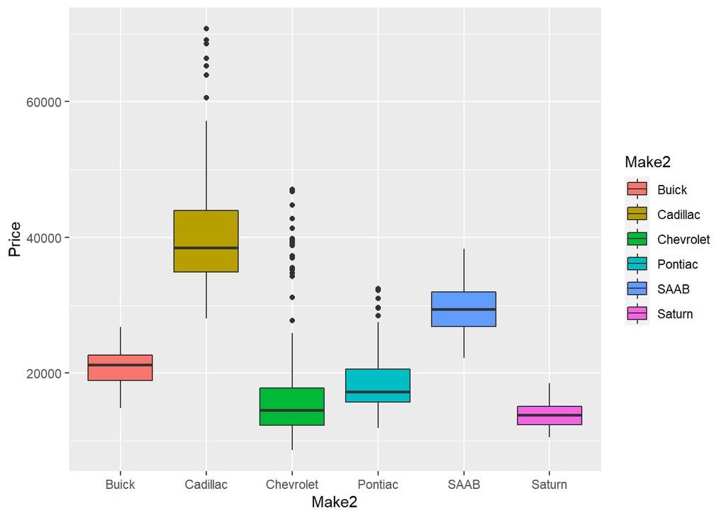

```r
#Box plots
used_cars2 %>%
  ggplot(aes(Make2, Price, fill = Make2)) +
    geom_boxplot()
```

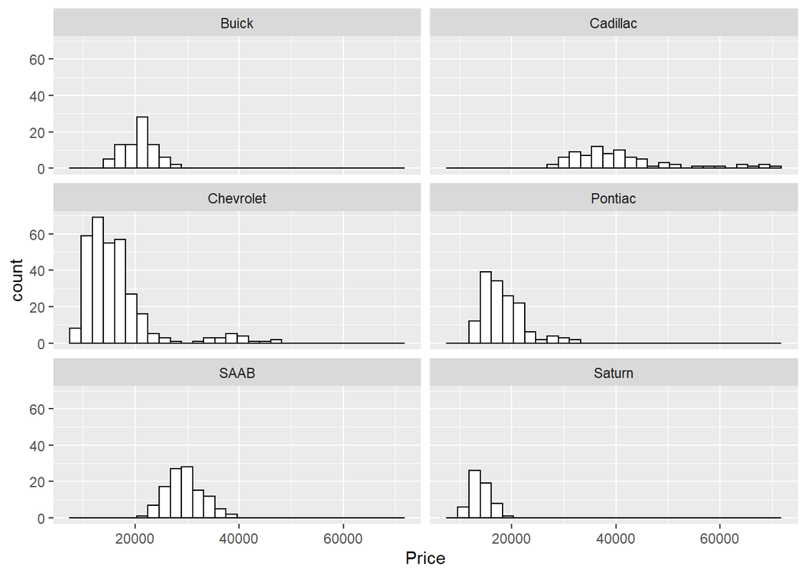

```r
#Histograms
ggplot(used_cars2, aes(x = Price)) +
  geom_histogram(fill = "white", colour = "black") +
  facet_wrap( ~ Make2, ncol = 2)
```

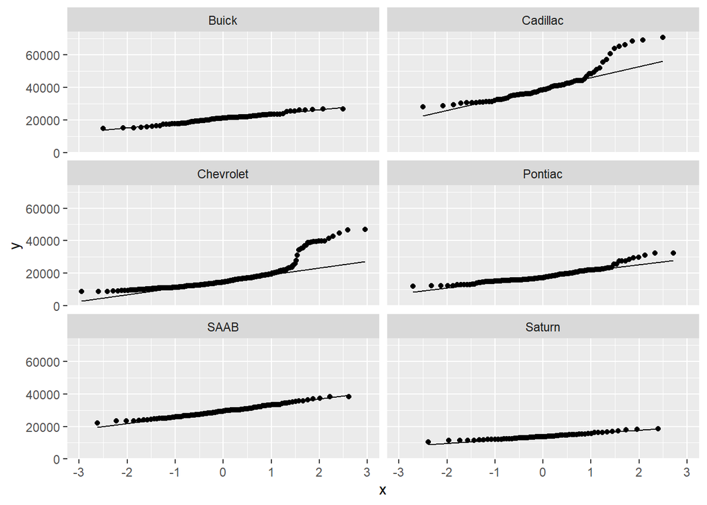

```r
#Q-Q plots
used_cars2 %>%
  ggplot() +
  geom_qq(mapping = aes(sample = Price)) +
  geom_qq_line(mapping = aes(sample = Price)) +
  facet_wrap(vars(Make2),nrow = 3)
```

- Writing R programs for simulation from probability models and randomization-based experiments

Honestly, I think this is the one part of the class that I really didn’t get a good handle on. I will have to go back through a couple of the activities to show that I can accomplish this before this reflection is officially do.

- Using source documentation and other resourced to troubleshoot and extend R programs.

Google has been my best friend in this class. Expectantly throughout the final project. While going thought the process of trying to use leaflet and shiny I have learned a lot from the Sinny app gallery and other people on the internet that have gotten the same errors as I have. That it the one nice things about R is most likely someone has run into the same problems that you have. I have used a bunch of different discussion board pages were people have put in there code to see if someone else would be able to look at it and find the mistake. A lot of the time I have the same exact error they do and am able to look in the comments to see what others have suggested to fix the error. It is super rare that no one has tried what you are doing before. So I am very grateful for everyone that has struggled before me so that I can learn from their mistakes as well. I also feel that getting errors also helps to get a better understanding of how code should be written. I have extended my knowledge of R extensively while trouble shooting and now have a much better understanding of what needs to be included in specific commands in order for them to run more smoothly.

- Write clear, efficient, and well-documented R programs

I think this will be best shown when I have finished the Shiny app side of the final project. I am still working through getting all of my sources together so that I can give credit to the code that has helped me through the process of writing this app. So I know I will need to add to this section once the final project is finished because as this moment I don’t have any other R programs and I feel would show what I have accomplished in this aspect of the class.

## Grade and Other Thoughts

I would give myself and A in this class, but I might change this if I am not able to show my ability to write an R program for simulations from probability models and randomization-based experiments. If I am able to show this I will keep it at an A. However, If I look back to what I was able to do at the beginning of the semester vs now I am amazed at what I have accomplished. I am much more confident in what I am able to do in R now vs the beginning of the semester. I also really appreciate the fact that we have been given room to fail in this class. Knowing that I haven’t been solely focused on getting a specific grade I know I have pushed myself to try and make the shiny app. I know I would have never tried to take on such a task if I was so focused on the grade and by pushing myself I have expaned my knowledge so much more.